# Kaggle challenge

Use this link for more information: https://www.kaggle.com/c/auto-insurance-fall-2017

#### Alhousseynou BALL alhousseynou.ball@polytechnique.edu

- I. Exploratory Data Analysis
  - I.1. Data preparation
    - a. Importation data
    - b. Remove dollars signs
  - I.2. Data visualisation
    - a. Graphic target features
    - b. Graphic categorical features
    - c. Graphic numerical features
  - I.3. Data Preprocessing
    - a. Undersampled data
    - b. Outliers treatment: sinus transformation
    - c. Impute missing values
    - d. Collinearity features
- II. Modelisation
  - II.1. Logistic Regression
  - II.2. Random Forest
  - II.3. Gradient Boosting
- III. Tuning model with Gridsearch
- IV. Predictions

# Setup

```python
import pandas as pd
import numpy as np
import re
import seaborn as sns
sns.set_palette(palette="Dark2")
import matplotlib.pyplot as plt
from sklearn.impute import SimpleImputer
from sklearn.pipeline import Pipeline
from sklearn.linear_model import LogisticRegression
from sklearn.ensemble import RandomForestClassifier
from sklearn.ensemble import GradientBoostingClassifier
from sklearn.model_selection import cross_validate
from sklearn.metrics import classification_report
from sklearn.model_selection import cross_val_predict
from sklearn.model_selection import GridSearchCV
from termcolor import colored
```

# I. Exploratory Data Analysis

| Variables | Description |
| --- | --- |
| TARGET_FLAG | Was Car in a crash? 1=YES 0=NO |
| TARGET_AMT | If car was in a crash, what was the cost |
| AGE | Age of Driver |
| BLUEBOOK | Value of Vehicle |
| CAR_AGE | Vehicle Age |
| CAR_TYPE | Type of Car |
| CAR_USE | Vehicle Use |
| CLM_FREQ | Claims (Past 5 Years) |
| EDUCATION | Max Education Level |
| HOMEKIDS | Children at Home |
| HOME_VAL | Home Value |
| INCOME | Income |
| JOB | Job Category |
| KIDSDRIV | Driving Children |
| MSTATUS | Marital Status |
| MVR_PTS | Motor Vehicle Record Points |
| OLDCLAIM | Total Claims Past 5 Years |
| PARENT1 | Single Parent |
| RED_CAR | A Red Car |
| REVOKED | License Revoked Past 7 Years |
| SEX | Gender |
| TIF | Time in Force |
| TRAVTIME | Distance to Work |
| URBANICITY | Home/Work Area |
| YOJ | Years on Job |

## I.1. Data preparation

### a. Importation data

```python
train = pd.read_csv('data/train_auto.csv', index_col=0)
test = pd.read_csv('data/test_auto.csv', index_col=0)

print("Size of train data: ", train.shape)
print("Size of test data : ", test.shape)
```

```
Size of train data:  (8161, 25)
Size of test data :  (2141, 25)
```

```python
pd.set_option('display.max_columns', None)
train.head()
```

| INDEX | TARGET_FLAG | TARGET_AMT | KIDSDRIV | AGE | HOMEKIDS | YOJ | INCOME | PARENT1 | HOME_VAL | MSTATUS | SEX | EDUCATION | JOB | TRAVTIME | CAR_USE | BLUEBOOK | TIF | CAR_TYPE | RED_CAR | OLDCLAIM | CLM_FREQ | REVOKED | MVR_PTS | CAR_AGE | URBANICITY |
| --- | --- | --- | --- | --- | --- | --- | --- | --- | --- | --- | --- | --- | --- | --- | --- | --- | --- | --- | --- | --- | --- | --- | --- | --- | --- |
| 1 | 0 | 0.0 | 0 | 60.0 | 0 | 11.0 | $67,349 | No | $0 | z_No | M | PhD | Professional | 14 | Private | $14,230 | 11 | Minivan | yes | $4,461 | 2 | No | 3 | 18.0 | Highly Urban/ Urban |
| 2 | 0 | 0.0 | 0 | 43.0 | 0 | 11.0 | $91,449 | No | $257,252 | z_No | M | z_High School | z_Blue Collar | 22 | Commercial | $14,940 | 1 | Minivan | yes | $0 | 0 | No | 0 | 1.0 | Highly Urban/ Urban |
| 4 | 0 | 0.0 | 0 | 35.0 | 1 | 10.0 | $16,039 | No | $124,191 | Yes | z_F | z_High School | Clerical | 5 | Private | $4,010 | 4 | z_SUV | no | $38,690 | 2 | No | 3 | 10.0 | Highly Urban/ Urban |
| 5 | 0 | 0.0 | 0 | 51.0 | 0 | 14.0 | NaN | No | $306,251 | Yes | M | <High School | z_Blue Collar | 32 | Private | $15,440 | 7 | Minivan | yes | $0 | 0 | No | 0 | 6.0 | Highly Urban/ Urban |
| 6 | 0 | 0.0 | 0 | 50.0 | 0 | NaN | $114,986 | No | $243,925 | Yes | z_F | PhD | Doctor | 36 | Private | $18,000 | 1 | z_SUV | no | $19,217 | 2 | Yes | 3 | 17.0 | Highly Urban/ Urban |

### b. Remove dollars signs

```python
dollars_columns = ['INCOME', 'HOME_VAL', 'BLUEBOOK', 'OLDCLAIM']
train[dollars_columns] = train[dollars_columns].replace('[\$,]', '', regex=True).astype(float)
test[dollars_columns] = test[dollars_columns].replace('[\$,]', '', regex=True).astype(float)
```

```python
train.head()
```

| INDEX | TARGET_FLAG | TARGET_AMT | KIDSDRIV | AGE | HOMEKIDS | YOJ | INCOME | PARENT1 | HOME_VAL | MSTATUS | SEX | EDUCATION | JOB | TRAVTIME | CAR_USE | BLUEBOOK | TIF | CAR_TYPE | RED_CAR | OLDCLAIM | CLM_FREQ | REVOKED | MVR_PTS | CAR_AGE | URBANICITY |
| --- | --- | --- | --- | --- | --- | --- | --- | --- | --- | --- | --- | --- | --- | --- | --- | --- | --- | --- | --- | --- | --- | --- | --- | --- | --- |
| 1 | 0 | 0.0 | 0 | 60.0 | 0 | 11.0 | 67349.0 | No | 0.0 | z_No | M | PhD | Professional | 14 | Private | 14230.0 | 11 | Minivan | yes | 4461.0 | 2 | No | 3 | 18.0 | Highly Urban/ Urban |
| 2 | 0 | 0.0 | 0 | 43.0 | 0 | 11.0 | 91449.0 | No | 257252.0 | z_No | M | z_High School | z_Blue Collar | 22 | Commercial | 14940.0 | 1 | Minivan | yes | 0.0 | 0 | No | 0 | 1.0 | Highly Urban/ Urban |
| 4 | 0 | 0.0 | 0 | 35.0 | 1 | 10.0 | 16039.0 | No | 124191.0 | Yes | z_F | z_High School | Clerical | 5 | Private | 4010.0 | 4 | z_SUV | no | 38690.0 | 2 | No | 3 | 10.0 | Highly Urban/ Urban |
| 5 | 0 | 0.0 | 0 | 51.0 | 0 | 14.0 | NaN | No | 306251.0 | Yes | M | <High School | z_Blue Collar | 32 | Private | 15440.0 | 7 | Minivan | yes | 0.0 | 0 | No | 0 | 6.0 | Highly Urban/ Urban |
| 6 | 0 | 0.0 | 0 | 50.0 | 0 | NaN | 114986.0 | No | 243925.0 | Yes | z_F | PhD | Doctor | 36 | Private | 18000.0 | 1 | z_SUV | no | 19217.0 | 2 | Yes | 3 | 17.0 | Highly Urban/ Urban |

```python
train.dtypes
```

```
TARGET_FLAG      int64
TARGET_AMT     float64
KIDSDRIV         int64
AGE            float64
HOMEKIDS         int64
YOJ            float64
INCOME         float64
PARENT1         object
HOME_VAL       float64
MSTATUS         object
SEX             object
EDUCATION       object
JOB             object
TRAVTIME         int64
CAR_USE         object
BLUEBOOK       float64
TIF              int64
CAR_TYPE        object
RED_CAR         object
OLDCLAIM       float64
CLM_FREQ         int64
REVOKED         object
MVR_PTS          int64
CAR_AGE        float64
URBANICITY      object
dtype: object
```

### I.2. Data visualisation

### a. Graphic target features

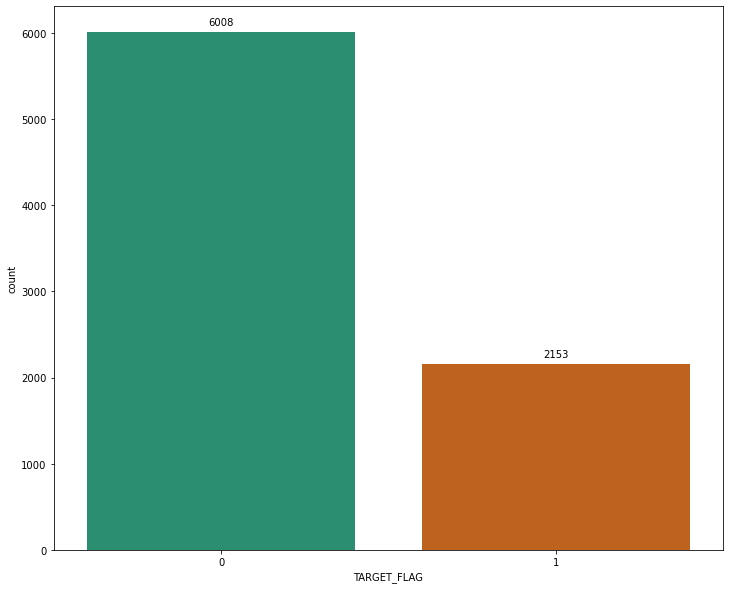

```python
fig = plt.figure(figsize=(12, 10))
ax = sns.countplot(x="TARGET_FLAG", data=train, order=train['TARGET_FLAG'].value_counts().index)
for p in ax.patches:
    ax.annotate(format(p.get_height()), (p.get_x() + p.get_width() / 2., p.get_height()),
               ha='center', va='center', xytext=(0, 10), textcoords='offset points')
```

- 26.3815% people reported Car in a crash
- Unbalanced Dataset

```python
nums_cols = list(train.select_dtypes(include=['int64', 'float64']).columns)
vars_to_remove = ['TARGET_FLAG', 'TARGET_AMT']
nums_cols = list(set(nums_cols) - set(vars_to_remove))
cats_cols = list(train.select_dtypes(include=['object']).columns)
```

### b. Graphic categorical features

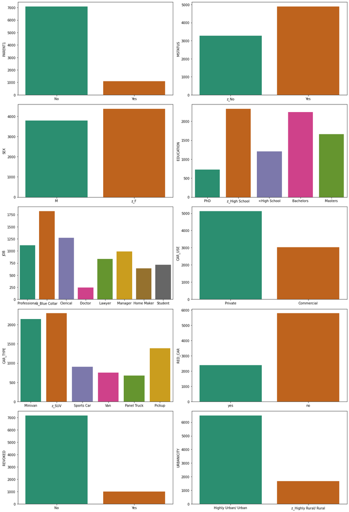

```python
fig, axes = plt.subplots(nrows=5, ncols=2, figsize=(15, 22))
for idx, col in enumerate(cats_cols):
    ax = axes[int(idx / 2), idx % 2]
    sns.countplot(x=col, data=train, ax=ax)
    ax.set_xlabel('')
    ax.set_ylabel(col)
fig.tight_layout()
```

**Interpretations graphic categorical features**

- The majority of customers have a High school or Bachelors
- Mostly urban customers
- The majority of customers haven't had their license revoked
- SUV and Minivan are the most used vehicles

### c. Graphic numerical features

```python
train[nums_cols].describe()
```

|  | OLDCLAIM | CLM_FREQ | KIDSDRIV | MVR_PTS | CAR_AGE | AGE | HOME_VAL | BLUEBOOK | TIF | INCOME | YOJ | TRAVTIME | HOMEKIDS |
| --- | --- | --- | --- | --- | --- | --- | --- | --- | --- | --- | --- | --- | --- |
| count | 8161.000000 | 8161.000000 | 8161.000000 | 8161.000000 | 7651.000000 | 8155.000000 | 7697.000000 | 8161.000000 | 8161.000000 | 7716.000000 | 7707.000000 | 8161.000000 | 8161.000000 |
| mean | 4037.076216 | 0.798554 | 0.171057 | 1.695503 | 8.328323 | 44.790313 | 154867.289723 | 15709.899522 | 5.351305 | 61898.094609 | 10.499286 | 33.485725 | 0.721235 |
| std | 8777.139104 | 1.158453 | 0.511534 | 2.147112 | 5.700742 | 8.627589 | 129123.774574 | 8419.734075 | 4.146635 | 47572.682808 | 4.092474 | 15.908333 | 1.116323 |
| min | 0.000000 | 0.000000 | 0.000000 | 0.000000 | -3.000000 | 16.000000 | 0.000000 | 1500.000000 | 1.000000 | 0.000000 | 0.000000 | 5.000000 | 0.000000 |
| 25% | 0.000000 | 0.000000 | 0.000000 | 0.000000 | 1.000000 | 39.000000 | 0.000000 | 9280.000000 | 1.000000 | 28097.000000 | 9.000000 | 22.000000 | 0.000000 |
| 50% | 0.000000 | 0.000000 | 0.000000 | 1.000000 | 8.000000 | 45.000000 | 161160.000000 | 14440.000000 | 4.000000 | 54028.000000 | 11.000000 | 33.000000 | 0.000000 |
| 75% | 4636.000000 | 2.000000 | 0.000000 | 3.000000 | 12.000000 | 51.000000 | 238724.000000 | 20850.000000 | 7.000000 | 85986.000000 | 13.000000 | 44.000000 | 1.000000 |
| max | 57037.000000 | 5.000000 | 4.000000 | 13.000000 | 28.000000 | 81.000000 | 885282.000000 | 69740.000000 | 25.000000 | 367030.000000 | 23.000000 | 142.000000 | 5.000000 |

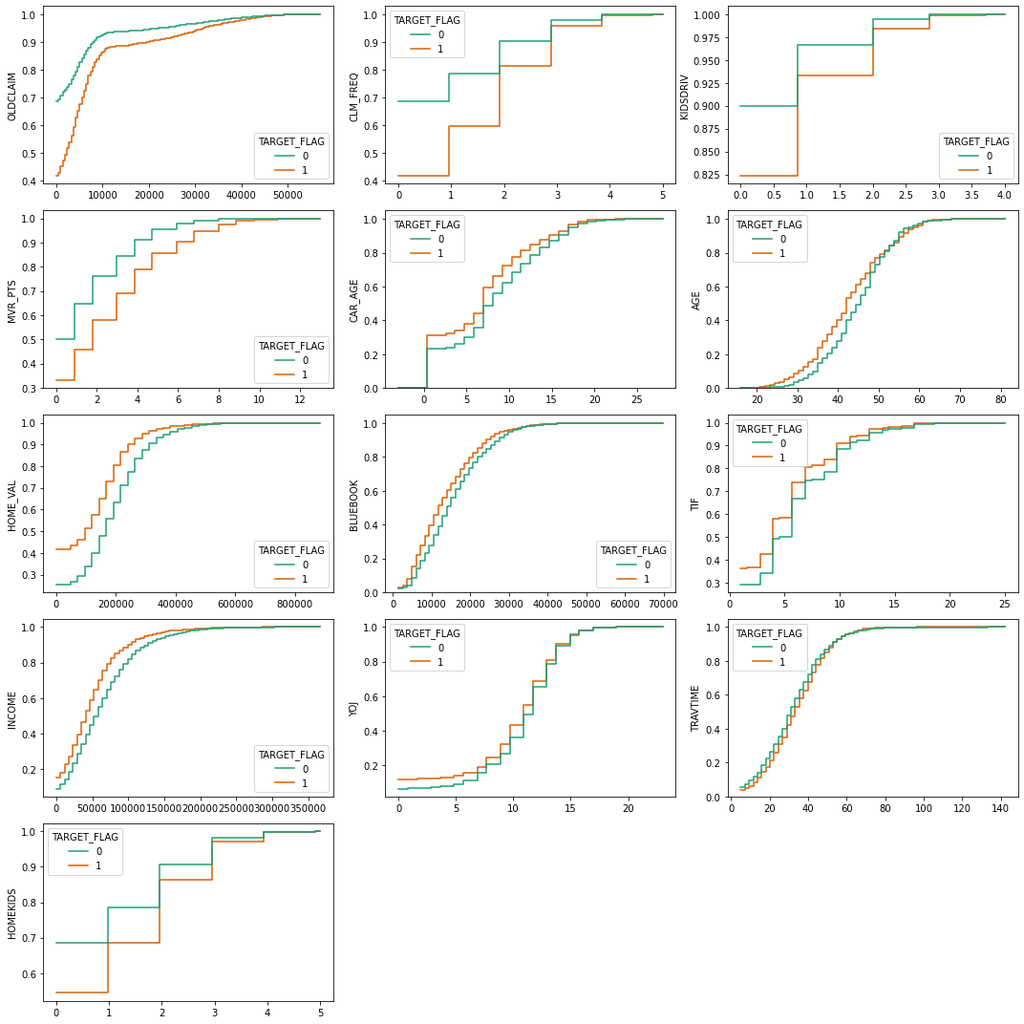

```python
# graphic Empirical Cumulative Distribution Function(ECDF)
fig, axes = plt.subplots(nrows=5, ncols=3, figsize=(15, 15))
axes[4, 1].axis('off')
axes[4, 2].axis('off')
for idx, col in enumerate(nums_cols):
    ax = axes[int(idx / 3), idx % 3]
    sns.histplot( data=train, x=col, hue="TARGET_FLAG", element="step", fill=False,
                 cumulative=True, stat="density", common_norm=False, ax=ax)
    ax.set_xlabel('')
    ax.set_ylabel(col)
fig.tight_layout()
```

**Interpretations graphic numerical features**

- Almost all the cars are between 0 and 20 years old
- 80% of the cars are less than 15 years old
- Slightly higher percentage for cars involved in a crash

### I.3 Data Preprocessing

### a. Undersampled data

```python
crash = len(train[train.TARGET_FLAG == 1])
no_crash_indices = train[train.TARGET_FLAG == 0].index
np.random.seed(seed=0)
random_indices = np.random.choice(no_crash_indices, crash, replace=False)
crash_indices = train[train.TARGET_FLAG == 1].index
under_sample_indices = np.concatenate([crash_indices, random_indices])
train = train.loc[under_sample_indices]
```

### b. Outliers treatment: sinus transformation

```python
def plot_outliers_transformers(feature):
    feature_val = train[feature]
    feature_sqrt = train[feature].apply(np.sqrt)
    feature_sin = train[feature].apply(np.sin)
    feature_log = train[feature].apply(np.log1p)

    fig, axes = plt.subplots(nrows=1, ncols=4, figsize=(15, 6))
    sns.boxplot(y=feature_val, ax=axes[0]).set_title(feature)
    sns.boxplot(y=feature_sqrt, ax=axes[1]).set(title=feature+'_sqrt', ylabel='')
    sns.boxplot(y=feature_sin, ax=axes[2]).set(title=feature+'_sin', ylabel='')
    sns.boxplot(y=feature_log, ax=axes[3]).set(title=feature+'_log1p', ylabel='')
    fig.tight_layout()
```

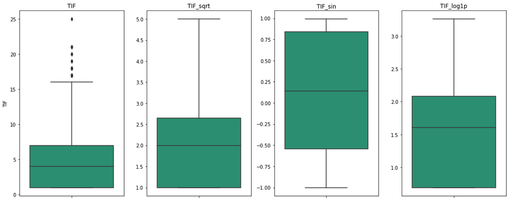

```python
plot_outliers_transformers('TIF')
```

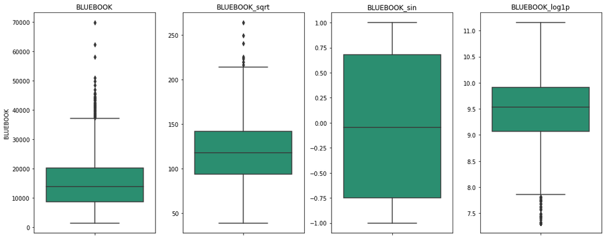

```python
plot_outliers_transformers('BLUEBOOK')
```

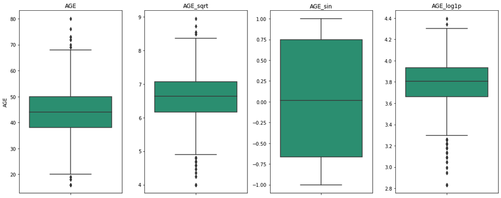

```python
plot_outliers_transformers('AGE')
```

```python
train[nums_cols] = train[nums_cols].apply(np.sin)
test[nums_cols] = test[nums_cols].apply(np.sin)
```

```python
X_train = train.drop(['TARGET_FLAG', 'TARGET_AMT'], axis=1)
y_train = train['TARGET_FLAG'].values

X_test = test.drop(['TARGET_FLAG', 'TARGET_AMT'], axis=1)
```

### c. Impute missing values

```python
X_train.isna().sum() / X_train.shape[0]
```

```
KIDSDRIV      0.000000
AGE           0.001393
HOMEKIDS      0.000000
YOJ           0.057362
INCOME        0.052485
PARENT1       0.000000
HOME_VAL      0.056433
MSTATUS       0.000000
SEX           0.000000
EDUCATION     0.000000
JOB           0.063864
TRAVTIME      0.000000
CAR_USE       0.000000
BLUEBOOK      0.000000
TIF           0.000000
CAR_TYPE      0.000000
RED_CAR       0.000000
OLDCLAIM      0.000000
CLM_FREQ      0.000000
REVOKED       0.000000
MVR_PTS       0.000000
CAR_AGE       0.060613
URBANICITY    0.000000
dtype: float64
```

```python
numeric_transformer = Pipeline(steps=[
    ('imputer', SimpleImputer(strategy='median'))])

categorical_transformer = Pipeline(steps=[
    ('imputer', SimpleImputer(strategy='most_frequent'))])
```

```python
train_cats_impute = pd.DataFrame(categorical_transformer.fit_transform(X_train[cats_cols]), columns = cats_cols)
train_nums_impute = pd.DataFrame(numeric_transformer.fit_transform(X_train[nums_cols]), columns = nums_cols)
X_train = pd.concat([train_cats_impute, train_nums_impute], axis=1, join='inner')

test_cats_impute = pd.DataFrame(categorical_transformer.transform(X_test[cats_cols]), columns = cats_cols)
test_nums_impute = pd.DataFrame(numeric_transformer.transform(X_test[nums_cols]), columns = nums_cols)
X_test = pd.concat([test_cats_impute, test_nums_impute], axis=1, join='inner')
```

```python
def encode_one_hot(df, features):
    dummies = pd.get_dummies(df[features])
    res = pd.concat([df, dummies], axis=1)
    res = res.drop(features, axis=1)
    return res

X_train = encode_one_hot(X_train, cats_cols)
X_test = encode_one_hot(X_test, cats_cols)
```

### d. Collinearity features

```python
regex = re.compile(r"\[|\]|<", re.IGNORECASE)
X_train.columns = [regex.sub("_", col) if any(x in str(col) for x in set(('[', ']', '<'))) else col for col in X_train.columns.values]
X_test.columns = [regex.sub("_", col) if any(x in str(col) for x in set(('[', ']', '<'))) else col for col in X_test.columns.values]
```

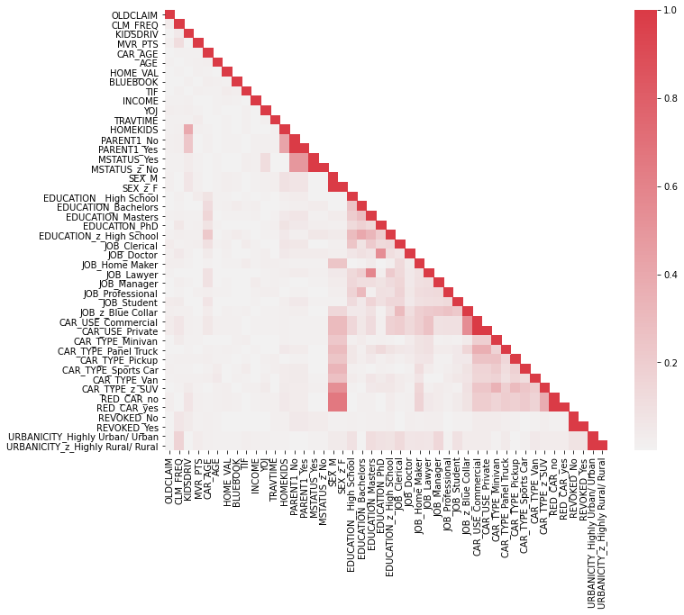

```python
corr_matrix = X_train.corr().abs()
mask = np.triu(np.ones(corr_matrix.shape), k=1).astype(np.bool)
upper = corr_matrix.where(mask)

f, ax = plt.subplots(figsize=(11, 9))
cmap = sns.diverging_palette(100, 10, as_cmap=True)
sns.heatmap(corr_matrix, mask=mask, cmap=cmap, center=0)
plt.show()
```

```python
collinearity_f = [column for column in upper.columns if any(upper[column] > 0.85)]
print("Collinearity features to be removed: ", collinearity_f)
X_train.drop(collinearity_f, axis=1, inplace=True)
X_test.drop(collinearity_f, axis=1, inplace=True)
```

```
Collinearity features to be removed:  ['PARENT1_Yes', 'MSTATUS_z_No', 'SEX_z_F', 'CAR_USE_Private', 'RED_CAR_yes', 'REVOKED_Yes', 'URBANICITY_z_Highly Rural/ Rural']
```

```python
print('X_train size: ', X_train.shape)
print('y_train size: ', y_train.shape)
print('X_test size: ', X_test.shape)
```

```
X_train size:  (4306, 39)
y_train size:  (4306,)
X_test size:  (2141, 39)
```

# II. Modelisation

## II.1. Logistic Regression ([LogisticRegression](https://scikit-learn.org/stable/modules/generated/sklearn.linear_model.LogisticRegression.html))

Logistic regression is a linear classification model

Score function: $ S(x) = a_1 * x_1 + a_2 * x_2 + \cdots + a_p * x_p $

$ P(y = 1|x) = logit(S(x)) = \frac{1}{1 + exp(S(x))} $

```python
lr = LogisticRegression(max_iter=1000)

cv_score = cross_validate(lr, X_train, y_train, scoring=['accuracy', 'f1_weighted', 'roc_auc'], cv=5)
print(colored('Accuracy: \t', 'blue'), colored(cv_score['test_accuracy'].mean(), 'blue'))
print(colored('F1 score: \t', 'blue'), colored(cv_score['test_f1_weighted'].mean(), 'blue'))
print(colored('Roc auc score: \t', 'blue'), colored(cv_score['test_roc_auc'].mean(), 'blue'))
```

```
Accuracy: 	 0.7180653801897648
F1 score: 	 0.7177303268349037
Roc auc score: 	 0.7818301310648856
```

```python
y_pred = cross_val_predict(lr, X_train, y_train, cv=5)
target_names = ['class 0', 'class 1']
print(classification_report(y_train, y_pred, target_names=target_names))
```

```
              precision    recall  f1-score   support

     class 0       0.73      0.69      0.71      2153
     class 1       0.71      0.74      0.73      2153

    accuracy                           0.72      4306
   macro avg       0.72      0.72      0.72      4306
weighted avg       0.72      0.72      0.72      4306
```

## II.2. Random Forest ([RandomForestClassifier](https://scikit-learn.org/stable/modules/generated/sklearn.ensemble.RandomForestClassifier.html))

Ensemble learning method for classification

Bootstrap aggregating to improve the stability and accuracy

Train each tree independently

```python
rf = RandomForestClassifier(random_state=0)

cv_score = cross_validate(rf, X_train, y_train, scoring=['accuracy', 'f1_weighted', 'roc_auc'], cv=5)
print(colored('Accuracy: \t', 'blue'), colored(cv_score['test_accuracy'].mean(), 'blue'))
print(colored('F1 score: \t', 'blue'), colored(cv_score['test_f1_weighted'].mean(), 'blue'))
print(colored('Roc auc score: \t', 'blue'), colored(cv_score['test_roc_auc'].mean(), 'blue'))
```

```
Accuracy: 	 0.7094736870471123
F1 score: 	 0.7090106111348794
Roc auc score: 	 0.7794551150559427
```

```python
y_pred = cross_val_predict(rf, X_train, y_train, cv=5)
target_names = ['class 0', 'class 1']
print(classification_report(y_train, y_pred, target_names=target_names))
```

```
              precision    recall  f1-score   support

     class 0       0.72      0.68      0.70      2153
     class 1       0.70      0.74      0.72      2153

    accuracy                           0.71      4306
   macro avg       0.71      0.71      0.71      4306
weighted avg       0.71      0.71      0.71      4306
```

## II.3. Gradient Boosting ([GradientBoostingClassifier](https://scikit-learn.org/stable/modules/generated/sklearn.ensemble.GradientBoostingClassifier.html))

Ensemble learning method for classification

Bootstrap aggregating to improve the stability and accuracy

Build trees one at a time, where each new tree helps to correct errors made by previously trained tree

```python
gb = GradientBoostingClassifier(random_state=0)

cv_score = cross_validate(gb, X_train, y_train, scoring=['accuracy', 'f1_weighted', 'roc_auc'], cv=5)
print(colored('Accuracy: \t', 'blue'), colored(cv_score['test_accuracy'].mean(), 'blue'))
print(colored('F1 score: \t', 'blue'), colored(cv_score['test_f1_weighted'].mean(), 'blue'))
print(colored('Roc auc score: \t', 'blue'), colored(cv_score['test_roc_auc'].mean(), 'blue'))
```

```
Accuracy: 	 0.721549431271575
F1 score: 	 0.7211608664995479
Roc auc score: 	 0.7930569074566055
```

```python
y_pred = cross_val_predict(gb, X_train, y_train, cv=5)
target_names = ['class 0', 'class 1']
print(classification_report(y_train, y_pred, target_names=target_names))
```

```
              precision    recall  f1-score   support

     class 0       0.74      0.69      0.71      2153
     class 1       0.71      0.75      0.73      2153

    accuracy                           0.72      4306
   macro avg       0.72      0.72      0.72      4306
weighted avg       0.72      0.72      0.72      4306
```

# III. Tuning model with Gridsearch

```python
params = {'learning_rate': [0.1, 0.05, 0.01],
          'n_estimators':  [100, 200, 300],
          'max_features' : ['sqrt', 'log2']
         }

gb = GradientBoostingClassifier(max_features='sqrt', random_state=0)
gb_grid = GridSearchCV(estimator=gb, param_grid=params, scoring='accuracy', n_jobs=-1, cv=5, verbose=1)
gb_grid.fit(X_train, y_train)
print('Best parameters : ', gb_grid.best_params_)
```

```
Fitting 5 folds for each of 18 candidates, totalling 90 fits
Best parameters :  {'learning_rate': 0.05, 'max_features': 'log2', 'n_estimators': 200}
```

```python
model = GradientBoostingClassifier(learning_rate=0.05, n_estimators=200, max_features='log2', random_state=0)

cv_score = cross_validate(model, X_train, y_train, scoring=['accuracy', 'f1_weighted', 'roc_auc'], cv=5)
print(colored('Accuracy: \t', 'blue'), colored(cv_score['test_accuracy'].mean(), 'blue'))
print(colored('F1 score: \t', 'blue'), colored(cv_score['test_f1_weighted'].mean(), 'blue'))
print(colored('Roc auc score: \t', 'blue'), colored(cv_score['test_roc_auc'].mean(), 'blue'))
```

```
Accuracy: 	 0.7250356381588343
F1 score: 	 0.7245206379490975
Roc auc score: 	 0.7955354961607958
```

```python
y_pred = cross_val_predict(model, X_train, y_train, cv=5)
target_names = ['class 0', 'class 1']
print(classification_report(y_train, y_pred, target_names=target_names))
```

```
              precision    recall  f1-score   support

     class 0       0.74      0.69      0.71      2153
     class 1       0.71      0.76      0.73      2153

    accuracy                           0.73      4306
   macro avg       0.73      0.73      0.72      4306
weighted avg       0.73      0.73      0.72      4306
```

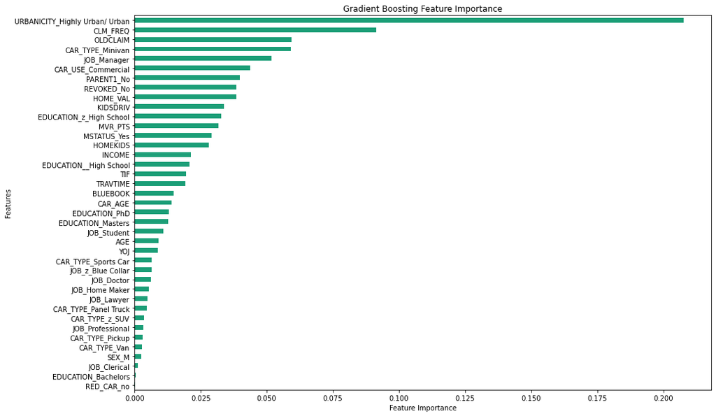

```python
model.fit(X_train, y_train)
features = list(X_train.columns)
feat_imp = pd.Series(model.feature_importances_, features).sort_values(ascending=True)
f, ax = plt.subplots(figsize=(15, 10))
feat_imp.plot(kind='barh', title='Gradient Boosting Feature Importance')
plt.xlabel('Feature Importance')
plt.ylabel('Features')
plt.show()
```

# IV. Predictions

```python
y_pred = model.predict(X_test)
pd.DataFrame(y_pred).to_csv("predictions.csv", index=False)
```

- I. Exploratory Data Analysis
  - I.1. Data preparation
    - a. Importation data
    - b. Remove dollars signs
  - I.2. Data visualisation
    - a. Graphic target features
    - b. Graphic categorical features
    - c. Graphic numerical features
  - I.3. Data Preprocessing
    - a. Undersampled data
    - b. Outliers treatment: sinus transformation
    - c. Impute missing values
    - d. Collinearity features
- II. Modelisation
  - II.1. Logistic Regression
  - II.2. Random Forest
  - II.3. Gradient Boosting
- III. Tuning model with Gridsearch
- IV. Predictions